# Python for Data Science

## Why Python?

### Scientific Python (SciPy) Ecosystem

Libraries are important characteristic of how Python works: each application has its libraries. For scientific computing, one can use a combination of the following packages that meets the need.

| Package | Description | Logo |
| --- | --- | --- |
| **Numpy** | Numerical arrays |  |
| Scipy | User-friendly and efficient numerical routines: numerical integration, interpolation, optimization, linear algebra, and statistics |  |
| **Jupyter Notebook** | Interactive programming environment |  |
| **Matplotlib** | Plotting |  |
| **Pandas** | Data analytics R-like data frames |  |
| Scikit-learn | Machine learning |  |

All the packages above are included in the [Anaconda distribution](https://www.anaconda.com/products/distribution) of Python. If you download Anaconda, it comes with all the useful scientific programming packages. Packages used in this workshop are in bold.

```python
import IPython
print(IPython.sys_info())
```

```
{'commit_hash': '3813660de',
 'commit_source': 'installation',
 'default_encoding': 'utf-8',
 'ipython_path': '/Users/kose/opt/anaconda3/lib/python3.9/site-packages/IPython',
 'ipython_version': '7.29.0',
 'os_name': 'posix',
 'platform': 'macOS-10.16-x86_64-i386-64bit',
 'sys_executable': '/Users/kose/opt/anaconda3/bin/python',
 'sys_platform': 'darwin',
 'sys_version': '3.9.7 (default, Sep 16 2021, 08:50:36) \n[Clang 10.0.0 ]'}
```

## Before We move on...

We have limited resources for each user on the cloud. Don't forget to shut down the kernels you are not using.

[figure not shown]

## Pandas

Pandas is a Python library for working with datasets. It supports data frame structure like in R.

```python
# load the pandas library
import pandas as pd
# we also load numpy for array computation for convenience
import numpy as np
import platform
mimic_path = "/Users/huazhou/Desktop/mimic-iv-1.0" if platform.uname().node == "RELMDOMFAC30610" else "/home/shared/1.0"
```

### Loading data

Let's load `icustays.csv.gz` file as a pandas data frame. We need to predetermine the columnes with date-time values.

```python
icustays_df = pd.read_csv(mimic_path + "/icu/icustays.csv.gz", parse_dates=["intime", "outtime"])
print(icustays_df)
```

```
       subject_id   hadm_id   stay_id  \
0        17867402  24528534  31793211
1        14435996  28960964  31983544
2        17609946  27385897  33183475
3        18966770  23483021  34131444
4        12776735  20817525  34547665
...           ...       ...       ...
76535    15368898  27299174  39990887
76536    15721773  28911582  39991872
76537    12275003  22562812  39992247
76538    17577670  24221219  39993265
76539    17840864  22695803  39999810

                                         first_careunit  \
0                                   Trauma SICU (TSICU)
```

[output cut: 38 more lines]

You may press `Shift-Tab` to see the function documentation interactively, or typing `?pd.read_csv` in the code cell.

```python
icustays_df.__class__
```

```
pandas.core.frame.DataFrame
```

The variable read in is an instance of `DataFrame`. Let's talk a little bit about what this means.

#### Note: Object-Oriented Programming

Python has built-in object-oriented programming (OOP) support. The OOP paradigm is based on "objects", which is bundled with data representing properties of the object and code in the form of method.

- **Class**: defines data format (attributes) and available procdeures (methods) for an object. `DataFrame`.
- **Object**: An instance of a class. `icustays_df`.
- **Attributes**: Properties like column names, number of rows, number of columns, etc. **syntax: `df.attribute`**
- **Methods**: "Actions" (or procedures/functions) applied to or performed on the object. **syntax: `df.method(arg1, arg2, etc.)`**

Now `admissions.csv.gz`:

```python
admissions_df = pd.read_csv(mimic_path + "/core/admissions.csv.gz",
                           parse_dates = ["admittime", "dischtime", "deathtime", "edregtime", "edouttime"])
print(admissions_df)
```

```
        subject_id   hadm_id           admittime           dischtime  \
0         14679932  21038362 2139-09-26 14:16:00 2139-09-28 11:30:00
1         15585972  24941086 2123-10-07 23:56:00 2123-10-12 11:22:00
2         11989120  21965160 2147-01-14 09:00:00 2147-01-17 14:25:00
3         17817079  24709883 2165-12-27 17:33:00 2165-12-31 21:18:00
4         15078341  23272159 2122-08-28 08:48:00 2122-08-30 12:32:00
...            ...       ...                 ...                 ...
523735    17892964  20786062 2180-09-17 00:00:00 2180-09-18 13:37:00
523736    17137572  20943099 2147-08-01 17:41:00 2147-08-02 17:30:00
523737    19389857  23176714 2189-03-01 00:58:00 2189-03-02 15:22:00
523738    12298845  22347500 2138-05-31 00:00:00 2138-06-04 16:50:00
523739    11211939  24981356 2147-08-02 15:49:00 2147-08-05 16:30:00

       deathtime               admission_type      admission_location  \
0            NaT                     ELECTIVE                     NaN
```

[output cut: 51 more lines]

And `patients.csv.gz`:

```python
patients_df = pd.read_csv(mimic_path + "/core/patients.csv.gz")
print(patients_df)
```

```
        subject_id gender  anchor_age  anchor_year anchor_year_group  dod
0         10000048      F          23         2126       2008 - 2010  NaN
1         10002723      F           0         2128       2017 - 2019  NaN
2         10003939      M           0         2184       2008 - 2010  NaN
3         10004222      M           0         2161       2014 - 2016  NaN
4         10005325      F           0         2154       2011 - 2013  NaN
...            ...    ...         ...          ...               ...  ...
382273    19998203      M          29         2132       2011 - 2013  NaN
382274    19998350      M          52         2127       2011 - 2013  NaN
382275    19999068      M          63         2161       2011 - 2013  NaN
382276    19999270      M          33         2184       2014 - 2016  NaN
382277    19999298      M          20         2177       2011 - 2013  NaN

[382278 rows x 6 columns]
```

For `chartevents_filtered_itemid.csv.gz`, we learn how to read in only selected columns.

```python
from timeit import default_timer as timer
```

```python
start = timer()
chartevents_df = pd.read_csv(
    mimic_path + "/icu/chartevents_filtered_itemid.csv.gz",
    usecols = ["stay_id", "itemid", "charttime", "valuenum"],
    dtype = {"stay_id" : np.float64, "itemid" : np.float64, "charttime" : "str", "valuenum" : np.float64},
    parse_dates = ["charttime"]
    )
end = timer()
print("Elapsed time: ", end - start)
```

```
Elapsed time:  10.231377217000002
```

```python
print(chartevents_df)
```

```
            stay_id           charttime    itemid  valuenum
0        30600691.0 2165-04-24 05:30:00  220045.0      65.0
1        30600691.0 2165-04-24 05:38:00  223761.0      97.6
2        30600691.0 2165-04-24 06:00:00  220045.0      56.0
3        30600691.0 2165-04-24 06:09:00  220045.0      55.0
4        30600691.0 2165-04-24 07:00:00  220045.0      57.0
...             ...                 ...       ...       ...
8394026  30143796.0 2161-08-30 18:00:00  220045.0      96.0
8394027  30143796.0 2161-08-30 19:00:00  220045.0      80.0
8394028  30143796.0 2161-08-30 20:00:00  220045.0      91.0
8394029  30143796.0 2161-08-30 20:00:00  223761.0      97.5
8394030  30143796.0 2161-08-30 21:00:00  220045.0      88.0

[8394031 rows x 4 columns]
```

For filtering, we can use the `query` method.

```python
chartevents_df.query("stay_id == 30600691 and itemid == 220045")
```

|  | stay_id | charttime | itemid | valuenum |
| --- | --- | --- | --- | --- |
| 0 | 30600691.0 | 2165-04-24 05:30:00 | 220045.0 | 65.0 |
| 2 | 30600691.0 | 2165-04-24 06:00:00 | 220045.0 | 56.0 |
| 3 | 30600691.0 | 2165-04-24 06:09:00 | 220045.0 | 55.0 |
| 4 | 30600691.0 | 2165-04-24 07:00:00 | 220045.0 | 57.0 |
| 6 | 30600691.0 | 2165-04-24 08:00:00 | 220045.0 | 56.0 |

And for plotting, we use the package `matplotlib`.

```python
import matplotlib.pyplot as plt
%matplotlib inline
```

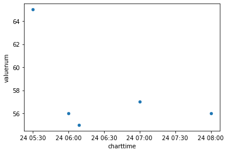

```python
(
    chartevents_df.query("stay_id == 30600691 and itemid == 220045").
        plot.scatter(x="charttime", y="valuenum")
)
```

#### Note: Method Chaining

One may use method chaining for linearizing method calls, as above. As the dot operator(`.`) is evaluated from left to right, one may "chain" another method call or attribute access right after obtaining the result of the previous method call or attribute access. This is a "pythonic" way of avoiding nested calls.

One limitation is that we can only do this for methods or attributes of a class. In this case, `print()` is not a method of `DataFrame`, we cannot chain `print` as what we did in R. One may use [`pandas.DataFrame.pipe()`](https://pandas.pydata.org/docs/reference/api/pandas.DataFrame.pipe.html) method for such operations. There are packages that implement pipe by overloading other operator (e.g., the bitwise or (`|`) operator).

## Target cohort (from R section)

Let's continue on with the task we did with R. We aim to develop a predictive model, which computes the chance of dying within 30 days of ICU stay `intime` based on baseline features

- `first_careunit`
- `age` at `intime`
- `gender`
- `ethnicity`
- first measurement of the following vitals since ICU stay `intime`
  - 220045 for heart rate
  - 223761 for Temperature Fahrenheit

We restrict to the first ICU stays of each unique patient.

## Wrangling and merging data frames

Our stragegy is

1. Identify and keep the first ICU stay of each patient.
2. Identify and keep the first vital measurements during the first ICU stay of each patient.
3. Join four data frames into a single data frame.

Important data wrangling concepts: group_by, sort, slice, joins, and pivot.

### Step 1: restrict to the first ICU stay of each patient

`icustays_df` has 76,540 rows, which is reduced to 53,150 unique ICU stays.

```python
icustays_df_1ststay = (icustays_df.sort_values(["subject_id", "intime"]).
                       groupby("subject_id").
                       head(1)) # head() is much faster than slice_head(n) in dplyr
print(icustays_df_1ststay)
```

```
       subject_id   hadm_id   stay_id  \
66220    10000032  29079034  39553978
57004    10000980  26913865  39765666
25744    10001217  24597018  37067082
10776    10001725  25563031  31205490
45299    10001884  26184834  37510196
...           ...       ...       ...
40352    19999442  26785317  32336619
20152    19999625  25304202  31070865
24802    19999828  25744818  36075953
56278    19999840  21033226  38978960
53712    19999987  23865745  36195440

                                         first_careunit  \
66220                Medical Intensive Care Unit (MICU)
```

[output cut: 38 more lines]

### Step 2: restrict to the first vital measurements during the ICU stay

Key data wrangling concepts: selecting columns, left_join, right_join, group_by, sort, pivot

```python
chartevents_df_1ststay = (
    chartevents_df.
    merge(
        icustays_df_1ststay[["stay_id", "intime", "outtime"]],
        how = "right",
        on = "stay_id"). # 15738363 rows
    query("charttime >= intime and charttime <= outtime"). # 15700234 rows
    sort_values(["stay_id", "itemid", "charttime"]).
    groupby(["stay_id", "itemid"]).
    head(1). # 263332 rows
    drop(["charttime", "intime", "outtime"], axis="columns"). # remove unnecessary columns
    astype({"itemid": str}). # change it to string for easier renaming
    pivot(index="stay_id", columns="itemid", values="valuenum").
    rename(columns={"220045.0": "heart_rate",
            "223761.0": "temp_f"})
)
```

```python
chartevents_df_1ststay
```

| itemid stay_id | heart_rate | temp_f |
| --- | --- | --- |
| 30000153.0 | 104.0 | 99.1 |
| 30000646.0 | 100.0 | 98.8 |
| 30001148.0 | 80.0 | 95.6 |
| 30001336.0 | 65.0 | 98.5 |
| 30001396.0 | 86.0 | 98.8 |
| ... | ... | ... |
| 39999286.0 | 125.0 | 98.9 |
| 39999384.0 | 77.0 | 98.2 |
| 39999552.0 | 66.0 | 98.2 |
| 39999562.0 | 93.0 | 98.4 |
| 39999810.0 | 71.0 | 98.1 |

53135 rows × 2 columns

### Step 3: merge DataFrames

New data wrangling concept: mutate. Pandas equivalent is `assign`.

```python
mimic_icu_cohort = (
    icustays_df_1ststay.
    # merge dataframes
    merge(admissions_df, on=["subject_id", "hadm_id"], how="left").
    merge(patients_df, on=["subject_id"], how="left").
    merge(chartevents_df_1ststay, on=["stay_id"], how="left").
    # age_intime is the age at the ICU stay intime
    assign(age_intime = lambda df:
           df["anchor_age"] + df["intime"].map(lambda x : x.year) - df["anchor_year"]).
    # whether the patient died within 30 days of ICU stay intime
    assign(hadm_to_death = lambda df:
           np.where(np.isnan(df["deathtime"]),
                    np.inf,
                    (df["deathtime"] - df["intime"]).dt.total_seconds())).
    assign(thirty_day_mort = lambda df: df["hadm_to_death"] <= 2592000)
)
```

```python
mimic_icu_cohort
```

|  | subject_id | hadm_id | stay_id | first_careunit | last_careunit | intime | outtime | los | admittime | dischtime | ... | gender | anchor_age | anchor_year | anchor_year_group | dod | heart_rate | temp_f | age_intime | hadm_to_death | thirty_day_mort |
| --- | --- | --- | --- | --- | --- | --- | --- | --- | --- | --- | --- | --- | --- | --- | --- | --- | --- | --- | --- | --- | --- |
| 0 | 10000032 | 29079034 | 39553978 | Medical Intensive Care Unit (MICU) | Medical Intensive Care Unit (MICU) | 2180-07-23 14:00:00 | 2180-07-23 23:50:47 | 0.410266 | 2180-07-23 12:35:00 | 2180-07-25 17:55:00 | ... | F | 52 | 2180 | 2014 - 2016 | NaN | 91.0 | 98.7 | 52 | inf | False |
| 1 | 10000980 | 26913865 | 39765666 | Medical Intensive Care Unit (MICU) | Medical Intensive Care Unit (MICU) | 2189-06-27 08:42:00 | 2189-06-27 20:38:27 | 0.497535 | 2189-06-27 07:38:00 | 2189-07-03 03:00:00 | ... | F | 73 | 2186 | 2008 - 2010 | NaN | 77.0 | 98.0 | 76 | inf | False |
| 2 | 10001217 | 24597018 | 37067082 | Surgical Intensive Care Unit (SICU) | Surgical Intensive Care Unit (SICU) | 2157-11-20 19:18:02 | 2157-11-21 22:08:00 | 1.118032 | 2157-11-18 22:56:00 | 2157-11-25 18:00:00 | ... | F | 55 | 2157 | 2011 - 2013 | NaN | 86.0 | 98.5 | 55 | inf | False |
| 3 | 10001725 | 25563031 | 31205490 | Medical/Surgical Intensive Care Unit (MICU/SICU) | Medical/Surgical Intensive Care Unit (MICU/SICU) | 2110-04-11 15:52:22 | 2110-04-12 23:59:56 | 1.338588 | 2110-04-11 15:08:00 | 2110-04-14 15:00:00 | ... | F | 46 | 2110 | 2011 - 2013 | NaN | 55.0 | 97.7 | 46 | inf | False |
| 4 | 10001884 | 26184834 | 37510196 | Medical Intensive Care Unit (MICU) | Medical Intensive Care Unit (MICU) | 2131-01-11 04:20:05 | 2131-01-20 08:27:30 | 9.171817 | 2131-01-07 20:39:00 | 2131-01-20 05:15:00 | ... | F | 68 | 2122 | 2008 - 2010 | 2131-01-20 | 38.0 | 98.1 | 77 | 780895.0 | True |
| ... | ... | ... | ... | ... | ... | ... | ... | ... | ... | ... | ... | ... | ... | ... | ... | ... | ... | ... | ... | ... | ... |
| 53145 | 19999442 | 26785317 | 32336619 | Surgical Intensive Care Unit (SICU) | Surgical Intensive Care Unit (SICU) | 2148-11-19 14:23:43 | 2148-11-26 13:12:15 | 6.950370 | 2148-11-19 10:00:00 | 2148-12-04 16:25:00 | ... | M | 41 | 2146 | 2008 - 2010 | NaN | 88.0 | 98.3 | 43 | inf | False |
| 53146 | 19999625 | 25304202 | 31070865 | Medical/Surgical Intensive Care Unit (MICU/SICU) | Medical/Surgical Intensive Care Unit (MICU/SICU) | 2139-10-10 19:18:00 | 2139-10-11 18:21:28 | 0.960741 | 2139-10-10 18:06:00 | 2139-10-16 03:30:00 | ... | M | 81 | 2138 | 2008 - 2010 | NaN | 96.0 | 98.9 | 82 | inf | False |
| 53147 | 19999828 | 25744818 | 36075953 | Medical Intensive Care Unit (MICU) | Medical Intensive Care Unit (MICU) | 2149-01-08 18:12:00 | 2149-01-10 13:11:02 | 1.790995 | 2149-01-08 16:44:00 | 2149-01-18 17:00:00 | ... | F | 46 | 2147 | 2017 - 2019 | NaN | 104.0 | 98.7 | 48 | inf | False |
| 53148 | 19999840 | 21033226 | 38978960 | Trauma SICU (TSICU) | Surgical Intensive Care Unit (SICU) | 2164-09-12 09:26:28 | 2164-09-17 16:35:15 | 5.297766 | 2164-09-10 13:47:00 | 2164-09-17 13:42:00 | ... | M | 58 | 2164 | 2008 - 2010 | 2164-09-17 | 100.0 | 99.3 | 58 | 447332.0 | True |
| 53149 | 19999987 | 23865745 | 36195440 | Trauma SICU (TSICU) | Trauma SICU (TSICU) | 2145-11-02 22:59:00 | 2145-11-04 21:29:30 | 1.937847 | 2145-11-02 21:38:00 | 2145-11-11 12:57:00 | ... | F | 57 | 2145 | 2011 - 2013 | NaN | 94.0 | 99.6 | 57 | inf | False |

53150 rows × 31 columns

## Data visualization

Remember we want to model:

thirty_day_mort ~ first_careunit + age_intime + gender + ethnicity + heart_rate + temp_f

Let's start with a numerical summary of variables of interest.

For numerical column, we can obtain mean, standard deviation, and quartiles using the method `describe()`. For a categorical column, we obtain number of unique values, value with the most appearance, and its frequency.

```python
(
    mimic_icu_cohort[["first_careunit",
        "gender",
        "ethnicity",
        "age_intime",
        "heart_rate",
        "temp_f"]].
    describe(include="all")
)
```

|  | first_careunit | gender | ethnicity | age_intime | heart_rate | temp_f |
| --- | --- | --- | --- | --- | --- | --- |
| count | 53150 | 53150 | 53150 | 53150.000000 | 53135.000000 | 52196.000000 |
| unique | 9 | 2 | 8 | NaN | NaN | NaN |
| top | Medical Intensive Care Unit (MICU) | M | WHITE | NaN | NaN | NaN |
| freq | 10233 | 29797 | 35668 | NaN | NaN | NaN |
| mean | NaN | NaN | NaN | 64.470461 | 87.466660 | 98.034339 |
| std | NaN | NaN | NaN | 17.315514 | 20.170132 | 3.345850 |
| min | NaN | NaN | NaN | 18.000000 | 0.000000 | 0.000000 |
| 25% | NaN | NaN | NaN | 54.000000 | 74.000000 | 97.600000 |
| 50% | NaN | NaN | NaN | 66.000000 | 85.000000 | 98.100000 |
| 75% | NaN | NaN | NaN | 78.000000 | 99.000000 | 98.700000 |
| max | NaN | NaN | NaN | 102.000000 | 941.000000 | 106.000000 |

Do you spot anything unusual?

To obtain counts of each value for categorical column, we use `value_counts()` method.

```python
mimic_icu_cohort["first_careunit"].value_counts()
```

```
Medical Intensive Care Unit (MICU)                  10233
Cardiac Vascular Intensive Care Unit (CVICU)         9450
Medical/Surgical Intensive Care Unit (MICU/SICU)     8833
Surgical Intensive Care Unit (SICU)                  8249
Trauma SICU (TSICU)                                  6965
Coronary Care Unit (CCU)                             6100
Neuro Surgical Intensive Care Unit (Neuro SICU)      1381
Neuro Intermediate                                   1312
Neuro Stepdown                                        627
Name: first_careunit, dtype: int64
```

```python
mimic_icu_cohort["gender"].value_counts()
```

```
M    29797
F    23353
Name: gender, dtype: int64
```

```python
mimic_icu_cohort["ethnicity"].value_counts()
```

```
WHITE                            35668
UNKNOWN                           5827
BLACK/AFRICAN AMERICAN            4874
OTHER                             2537
HISPANIC/LATINO                   1827
ASIAN                             1564
UNABLE TO OBTAIN                   759
AMERICAN INDIAN/ALASKA NATIVE       94
Name: ethnicity, dtype: int64
```

### Univariate summaries

Before we start, let's import the `seaborn` package for styling the figures a little bit (looking like ggplot2). This package is for statistical data visualization.

```python
import seaborn as sns
sns.set()
```

Bar plot of `first_careunit`

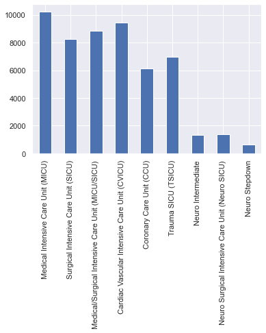

```python
mimic_icu_cohort["first_careunit"].value_counts(sort=False).plot.bar()
```

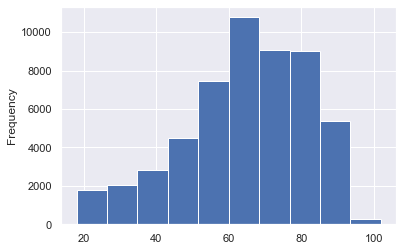

```python
mimic_icu_cohort["age_intime"].plot.hist()
```

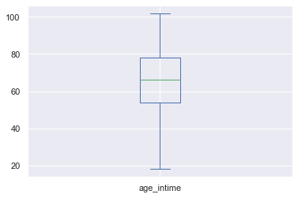

```python
mimic_icu_cohort["age_intime"].plot.box()
```

Histogram and boxplot of `age_intime`

#### Exercises

1. Summarize discrete variables: `gender`, `ethnicity`.
2. Summarize continuous variables: `heart_rate`, `temp_f`.
3. Is there anything unusual about `temp_f`?

### Bivariate summaries

Tally of `thirty_day_mort` vs `first_careunit`.

We need to be a little more verbose for plotting frequencies in stacked barplot in Python.

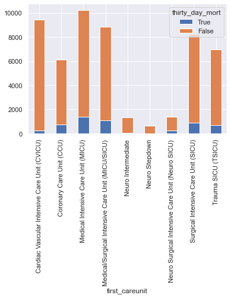

```python
(mimic_icu_cohort.
     groupby("first_careunit")["thirty_day_mort"].value_counts().
     unstack("thirty_day_mort").iloc[:, ::-1]. # reversing column order to make True come first
 plot.bar(stacked=True)
)
```

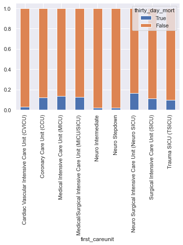

```python
(mimic_icu_cohort.
     groupby("first_careunit")["thirty_day_mort"].value_counts(normalize=True).
     unstack("thirty_day_mort").iloc[:, ::-1].
     plot.bar(stacked=True)
)
```

Tally of `thirty_day_mort` vs `gender`

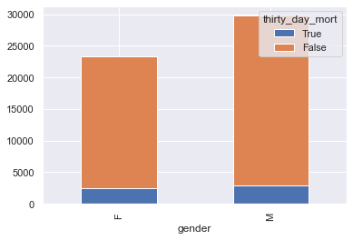

```python
(mimic_icu_cohort.
     groupby("gender")["thirty_day_mort"].value_counts(normalize=False).
     unstack("thirty_day_mort").iloc[:, ::-1].
     plot.bar(stacked=True)
)
```

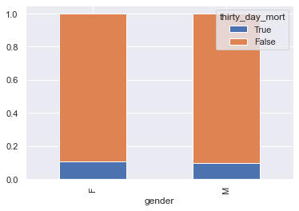

```python
(mimic_icu_cohort.
     groupby("gender")["thirty_day_mort"].value_counts(normalize=True).
     unstack("thirty_day_mort").iloc[:, ::-1].
     plot.bar(stacked=True)
)
```

```python
mimic_icu_cohort.groupby("gender")["thirty_day_mort"].value_counts(normalize=True).unstack("thirty_day_mort")
```

| thirty_day_mort gender | False | True |
| --- | --- | --- |
| F | 0.895088 | 0.104912 |
| M | 0.904420 | 0.095580 |

#### Exercises

1. Graphical summaries of `thirty_day_mort` vs other predictors.

## Pros and Cons of Python

**Pros**:

- General purpose $\rightarrow$ can directly use the data analysis result to different disciplines
- Wide user base $\rightarrow$ rich package ecosystem
- Readable and fast

**Cons**:

- Less statistical analysis packages
- Libraries may be more hard to understand
- Visualization is more convoluted than R